# VictorChendra_202000338_UTS_IBDA3111

## Prapemrosesan & Rekayasa Data - IBDA3111

### UTS - Students Performance in Exams

#### Victor Chendra - **202000338**

#### Description:

1. Masalah yang akan diselesaikan
1. How effective is the test preparation course?
2. Which major factors contribute to test outcomes?
3. What would be the best way to improve student scores on each test?
4. What patterns and interactions in the data can you find?
2. Deskripsi singkat dataset
- Students Performance in Exams dataset adalah sebuah dataset yang menggambarkan tentang peforma ujian siswa. Dalam dataset berisikan tentang nilai-nilai ujian siswa di sekolah. Adapun tabel-tabel yang terdapat di dalam dataset. (exams.csv)  
  Terdapat 8 kolom, 5 string 3 integers dan 1000 baris data. Dataset ini ingin memberikan gambaran, apakah pengaruh latar belakang orang tua, persiapan ujian, dan lain-lain terhadap kinerja ujian siswa.
3. Sumber dataset
- Dataset diperoleh dari kaggle.com  
  https://www.kaggle.com/datasets/whenamancodes/students-performance-in-exams
4. Cara memperoleh dataset
- Dataset diperoleh dengan cara mengunduh dari website.

### Library

```python
# Import library needed

import numpy as np
import pandas as pd
import seaborn as sns
import matplotlib.pyplot as plt

from numpy import mean
from numpy import std
from sklearn.model_selection import train_test_split
from sklearn.datasets import make_classification
from sklearn.model_selection import cross_val_score
from sklearn.preprocessing import OneHotEncoder
from sklearn.feature_selection import VarianceThreshold
from sklearn.feature_selection import RFE
from sklearn.tree import DecisionTreeClassifier
from sklearn.model_selection import RepeatedStratifiedKFold
from sklearn.linear_model import LogisticRegression
from sklearn.linear_model import Perceptron
from sklearn.ensemble import RandomForestClassifier
from sklearn.ensemble import GradientBoostingClassifier
from sklearn.pipeline import Pipeline
from sklearn import linear_model
from sklearn.feature_selection import SelectKBest
from sklearn.feature_selection import chi2

from matplotlib import pyplot
```

### Load and check dataset

```python
# Load dataset
df = pd.read_csv('exams.csv', delimiter=',')

# Show dataset
# pd.set_option('display.max_rows', None) # display all rows dataset
display(df.head(5))

# Dataset shape
print(f"Rows   : {df.shape[0]}\nColumns: {df.shape[1]}")
```

|  | gender | race/ethnicity | parental level of education | lunch | test preparation course | math score | reading score | writing score |
| --- | --- | --- | --- | --- | --- | --- | --- | --- |
| 0 | male | group A | high school | standard | completed | 67 | 67 | 63 |
| 1 | female | group D | some high school | free/reduced | none | 40 | 59 | 55 |
| 2 | male | group E | some college | free/reduced | none | 59 | 60 | 50 |
| 3 | male | group B | high school | standard | none | 77 | 78 | 68 |
| 4 | male | group E | associate's degree | standard | completed | 78 | 73 | 68 |

```
Rows   : 1000
Columns: 8
```

```python
# Check the datatype for all the column values
df.dtypes
```

```
gender                         object
race/ethnicity                 object
parental level of education    object
lunch                          object
test preparation course        object
math score                      int64
reading score                   int64
writing score                   int64
dtype: object
```

```python
# Check unique values columns
df.nunique()
```

```
gender                          2
race/ethnicity                  5
parental level of education     6
lunch                           2
test preparation course         2
math score                     77
reading score                  73
writing score                  76
dtype: int64
```

```python
# Let's check if the data has some missing values
print(f"Check if the data has some missing values")
df.isnull().sum()
```

```
Check if the data has some missing values
```

```
gender                         0
race/ethnicity                 0
parental level of education    0
lunch                          0
test preparation course        0
math score                     0
reading score                  0
writing score                  0
dtype: int64
```

↑ There are no missing values in the dataset* ↑

```python
# Let's check if the values of the first 5 columns numerical or categirical
for i in range(5):
    print(f"{df[df.columns[i]].value_counts()}\n")
```

```
male      517
female    483
Name: gender, dtype: int64

group C    323
group D    262
group B    205
group E    131
group A     79
Name: race/ethnicity, dtype: int64

some college          222
associate's degree    203
high school           202
some high school      191
bachelor's degree     112
master's degree        70
Name: parental level of education, dtype: int64

standard        652
free/reduced    348
Name: lunch, dtype: int64

none         665
completed    335
Name: test preparation course, dtype: int64
```

↑↑↑ We can see from the output above that the first 5 columns are categorical variables. Then, the rest columns are numerical variables.

```python
df.iloc[:, 5:].describe()
```

|  | math score | reading score | writing score |
| --- | --- | --- | --- |
| count | 1000.000000 | 1000.000000 | 1000.000000 |
| mean | 66.396000 | 69.002000 | 67.738000 |
| std | 15.402871 | 14.737272 | 15.600985 |
| min | 13.000000 | 27.000000 | 23.000000 |
| 25% | 56.000000 | 60.000000 | 58.000000 |
| 50% | 66.500000 | 70.000000 | 68.000000 |
| 75% | 77.000000 | 79.000000 | 79.000000 |
| max | 100.000000 | 100.000000 | 100.000000 |

↑↑ Let's see the statistic presentation using .describe()

[output not shown]

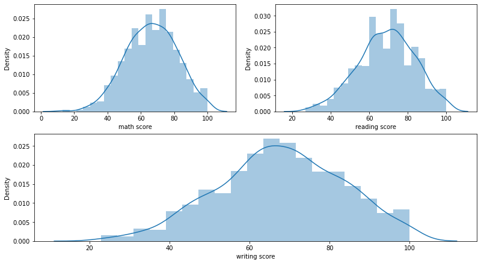

```python
figure, ax = plt.subplots(2,2, constrained_layout=True, figsize=(11, 6))

plt.subplot(2, 2, 1)
sns.distplot(df['math score'])

plt.subplot(2, 2, 2)
sns.distplot(df['reading score'])

plt.subplot(2, 2, (3, 4))
sns.distplot(df['writing score'])
```

↑ ↑ Let's see the distribution

↑ ↑ Let's see the distribution of the scores.

### 1. Data cleaning

##### 1. Delete duplicated rows

```python
# Delete duplicated rows
dups = df.duplicated()
print(f"Duplicated rows:")
print(dups.any())
print(df[dups])

print(f"\nShape before delete:  {df.shape}")
df.drop_duplicates(inplace=True)
print(f"Shape after delete :  {df.shape}\n")
```

```
Duplicated rows:
True
    gender race/ethnicity parental level of education     lunch  \
825   male        group E          associate's degree  standard

    test preparation course  math score  reading score  writing score
825               completed         100            100            100

Shape before delete:  (1000, 8)
Shape after delete :  (999, 8)
```

##### 2. Identifikasi Pencilan lalu diimputasi ke nilai lower bound

```
Outlier
    Math score    = [23, 13, 13]
    Writing score = [28, 29, 27, 28, 31, 29]
    Reading score = [24, 23, 26, 23]
```

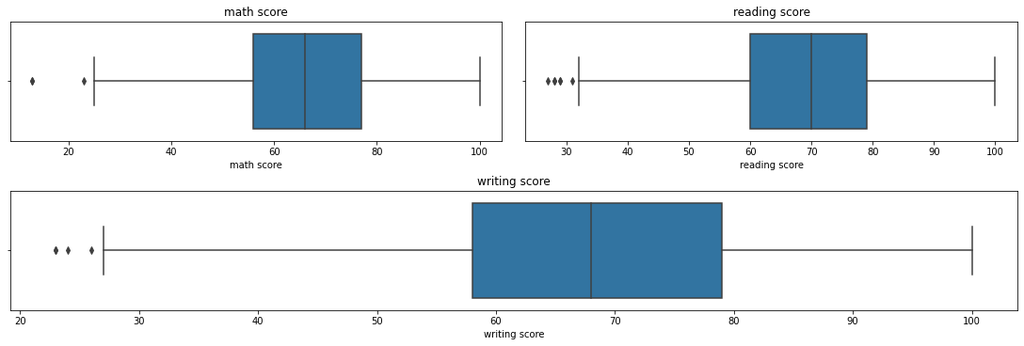

```python
# This func return upper & lower bound from dataset column
def identify_outlier(df_column):
    Q1, Q3 = np.percentile(df_column, [25, 75])
    IQR = Q3 - Q1
    lower_range = Q1 - (1.5 * IQR)
    upper_range = Q3 + (1.5 * IQR)

    return lower_range, upper_range


# Plot to boxplot so we can see the outlier data
def display_boxplot():
    figure, ax = plt.subplots(2,2, constrained_layout=True, figsize=(15, 5))

    s = 1
    for i in range(len(df.columns)):
        if i == 7:
            plt.subplot(2, 2, (s, s+1))
            plt.title(df.columns[i])
            sns.boxplot(x=df.iloc[:, i])
            s += 1
            continue

        if i >= 5:
            plt.subplot(2, 2, s)
            plt.title(df.columns[i])
            sns.boxplot(x=df.iloc[:, i])
            s += 1


# Take the bounderies value
math_score = identify_outlier(df.iloc[:, 5])
reading_score = identify_outlier(df.iloc[:, 6])
writing_score = identify_outlier(df.iloc[:, 7])

# Capture outlier (lower bound)
outlier_ms = [x for x in df.iloc[:, 5] if x < math_score[0]]
outlier_rs = [x for x in df.iloc[:, 6] if x < reading_score[0]]
outlier_ws = [x for x in df.iloc[:, 7] if x < writing_score[0]]

print(f"Outlier")
print(f"    Math score    = {outlier_ms}")
print(f"    Writing score = {outlier_rs}")
print(f"    Reading score = {outlier_ws}")

display_boxplot()
```

↑↑ From boxplot above.. we can see that there is an outlier in our dataset

```
Outlier
    Math score    = []
    Writing score = []
    Reading score = []
```

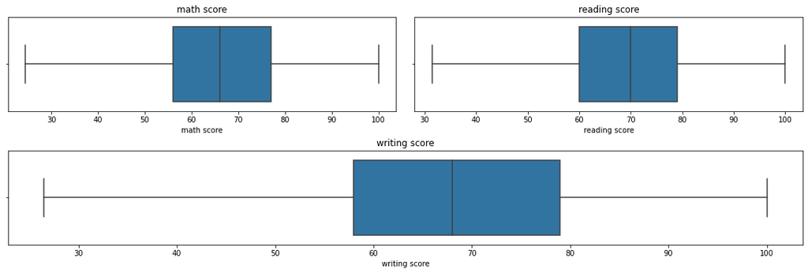

```python
# Function to impute to our dataset
def impute_outlier_to_lower_bound_value(df: pd.DataFrame, bounderies: tuple, n_col: int):
    for i in range(df.shape[0]):
        if df.iloc[i, n_col] <= bounderies[0]:
            df.iloc[i, n_col] = bounderies[0]
    return

impute_outlier_to_lower_bound_value(df, math_score, 5)
impute_outlier_to_lower_bound_value(df, reading_score, 6)
impute_outlier_to_lower_bound_value(df, writing_score, 7)

# Take the bounderies value
math_score = identify_outlier(df.iloc[:, 5])
reading_score = identify_outlier(df.iloc[:, 6])
writing_score = identify_outlier(df.iloc[:, 7])

# Capture outlier (lower bound)
outlier_ms = [x for x in df.iloc[:, 5] if x < math_score[0]]
outlier_rs = [x for x in df.iloc[:, 6] if x < reading_score[0]]
outlier_ws = [x for x in df.iloc[:, 7] if x < writing_score[0]]

print(f"Outlier")
print(f"    Math score    = {outlier_ms}")
print(f"    Writing score = {outlier_rs}")
print(f"    Reading score = {outlier_ws}")

display_boxplot()
```

↑ ↑ Now, we have done imputing the outlier data to it's lower bound value (so no more outlier)

We impute the outlier to it's lower bound because there are just a few outlier and we need it, so we don't delete the outlier data

### 2. Features selection

#### 1. RFE

↓↓ Adding columns “total” and “average” to the dataset

```python
# Display dataset before one hot encoding (after data cleaning)
display(df.head(2))
print(df.shape)

# Adding columns “total” and “average” to the dataset
df['total'] = df['math score'] + df['reading score'] + df['writing score']
df['average'] = df['total'] / 3
df.drop(["total"], axis=1, inplace=True)

print()
display(df.head(2))
print(df.shape)
```

|  | gender | race/ethnicity | parental level of education | lunch | test preparation course | math score | reading score | writing score |
| --- | --- | --- | --- | --- | --- | --- | --- | --- |
| 0 | male | group A | high school | standard | completed | 67.0 | 67.0 | 63.0 |
| 1 | female | group D | some high school | free/reduced | none | 40.0 | 59.0 | 55.0 |

```
(999, 8)
```

|  | gender | race/ethnicity | parental level of education | lunch | test preparation course | math score | reading score | writing score | average |
| --- | --- | --- | --- | --- | --- | --- | --- | --- | --- |
| 0 | male | group A | high school | standard | completed | 67.0 | 67.0 | 63.0 | 65.666667 |
| 1 | female | group D | some high school | free/reduced | none | 40.0 | 59.0 | 55.0 | 51.333333 |

```
(999, 9)
```

↓↓ One hot encoding

```python
# Create a function for one hot encoding (only variable input)
def one_hot_encoding(df):
    encoded = pd.get_dummies(df.iloc[:, :-4])
    ms = df.iloc[:, -4]
    rs = df.iloc[:, -3]
    ws = df.iloc[:, -2]
    avg = df.iloc[:, -1]

    encoded["math score"] = ms
    encoded["reading score"] = rs
    encoded["writing score"] = ws
    encoded["average"] = avg

    return encoded


# ----- Save it for later -----
# Original output
saved_mathscore = df.iloc[:, -4]
save_readingscore = df.iloc[:, -3]
save_writingscore = df.iloc[:, -2]
save_average = df.iloc[:, -1]

# before one hot encoding
display(df.head(3))
df.shape

# Make sure to run it just ONCE otherwise, you need to run it all again from begining
df_encoded = one_hot_encoding(df)

# after one hot encoding
display(df_encoded.head(3))
df_encoded.shape

# Adding new column indicates pass or not the exams
# if it's under 60, it's fail else they pass the test
df_encoded['math_PassStatus'] = np.where(df_encoded['math score']<60, 0, 1)
df_encoded['read_PassStatus'] = np.where(df_encoded['reading score']<60, 0, 1)
df_encoded['write_PassStatus'] = np.where(df_encoded['writing score']<60, 0, 1)
df_encoded['overall_PassStatus'] = np.where(df_encoded['average']<60, 0, 1)

# After added, we drop the column
df_encoded.drop(['math score'], axis=1, inplace=True)
df_encoded.drop(['reading score'], axis=1, inplace=True)
df_encoded.drop(['writing score'], axis=1, inplace=True)
df_encoded.drop(['average'], axis=1, inplace=True)

# FINAL DATASET
display(df_encoded.head(3))
df_encoded.shape
```

|  | gender | race/ethnicity | parental level of education | lunch | test preparation course | math score | reading score | writing score | average |
| --- | --- | --- | --- | --- | --- | --- | --- | --- | --- |
| 0 | male | group A | high school | standard | completed | 67.0 | 67.0 | 63.0 | 65.666667 |
| 1 | female | group D | some high school | free/reduced | none | 40.0 | 59.0 | 55.0 | 51.333333 |
| 2 | male | group E | some college | free/reduced | none | 59.0 | 60.0 | 50.0 | 56.333333 |

|  | gender_female | gender_male | race/ethnicity_group A | race/ethnicity_group B | race/ethnicity_group C | race/ethnicity_group D | race/ethnicity_group E | parental level of education_associate's degree | parental level of education_bachelor's degree | parental level of education_high school | ... | parental level of education_some college | parental level of education_some high school | lunch_free/reduced | lunch_standard | test preparation course_completed | test preparation course_none | math score | reading score | writing score | average |
| --- | --- | --- | --- | --- | --- | --- | --- | --- | --- | --- | --- | --- | --- | --- | --- | --- | --- | --- | --- | --- | --- |
| 0 | 0 | 1 | 1 | 0 | 0 | 0 | 0 | 0 | 0 | 1 | ... | 0 | 0 | 0 | 1 | 1 | 0 | 67.0 | 67.0 | 63.0 | 65.666667 |
| 1 | 1 | 0 | 0 | 0 | 0 | 1 | 0 | 0 | 0 | 0 | ... | 0 | 1 | 1 | 0 | 0 | 1 | 40.0 | 59.0 | 55.0 | 51.333333 |
| 2 | 0 | 1 | 0 | 0 | 0 | 0 | 1 | 0 | 0 | 0 | ... | 1 | 0 | 1 | 0 | 0 | 1 | 59.0 | 60.0 | 50.0 | 56.333333 |

3 rows × 21 columns

|  | gender_female | gender_male | race/ethnicity_group A | race/ethnicity_group B | race/ethnicity_group C | race/ethnicity_group D | race/ethnicity_group E | parental level of education_associate's degree | parental level of education_bachelor's degree | parental level of education_high school | ... | parental level of education_some college | parental level of education_some high school | lunch_free/reduced | lunch_standard | test preparation course_completed | test preparation course_none | math_PassStatus | read_PassStatus | write_PassStatus | overall_PassStatus |
| --- | --- | --- | --- | --- | --- | --- | --- | --- | --- | --- | --- | --- | --- | --- | --- | --- | --- | --- | --- | --- | --- |
| 0 | 0 | 1 | 1 | 0 | 0 | 0 | 0 | 0 | 0 | 1 | ... | 0 | 0 | 0 | 1 | 1 | 0 | 1 | 1 | 1 | 1 |
| 1 | 1 | 0 | 0 | 0 | 0 | 1 | 0 | 0 | 0 | 0 | ... | 0 | 1 | 1 | 0 | 0 | 1 | 0 | 0 | 0 | 0 |
| 2 | 0 | 1 | 0 | 0 | 0 | 0 | 1 | 0 | 0 | 0 | ... | 1 | 0 | 1 | 0 | 0 | 1 | 0 | 1 | 0 | 0 |

3 rows × 21 columns

```
(999, 21)
```

↑ ↑ Done One Hot Encoding ✔

```python
"""
This templates function is given from my teacher's jupyter notebook "RFE.ipynb" / from books "Data Preparation for
Machine Learning - Jason Brownlee"
"""

# get a list of models to evaluate
def get_models(X, y, n: int):
    models = dict()
    # lr
    rfe = RFE(estimator=LogisticRegression(), n_features_to_select=n)
    model = DecisionTreeClassifier()
    models['log reg'] = Pipeline(steps=[('s',rfe),('m',model)])
    # cart
    rfe = RFE(estimator=DecisionTreeClassifier(), n_features_to_select=n)
    model = DecisionTreeClassifier()
    models['cart'] = Pipeline(steps=[('s',rfe),('m',model)])
    # perceptron
    rfe = RFE(estimator=Perceptron(), n_features_to_select=n)
    model = DecisionTreeClassifier()
    models['perceptron'] = Pipeline(steps=[('s',rfe),('m',model)])
    # rf
    rfe = RFE(estimator=RandomForestClassifier(), n_features_to_select=n)
    model = DecisionTreeClassifier()
    models['rand forest'] = Pipeline(steps=[('s',rfe),('m',model)])
    # gbm
    rfe = RFE(estimator=GradientBoostingClassifier(), n_features_to_select=n)
    model = DecisionTreeClassifier()
    models['gbm'] = Pipeline(steps=[('s',rfe),('m',model)])
    return models


# evaluate a given model using cross-validation
def evaluate_model(model, X, y):
    cv = RepeatedStratifiedKFold(n_splits=10, n_repeats=3, random_state=1)
    scores = cross_val_score(model, X, y, scoring='accuracy', cv=cv, n_jobs=-1)
    return scores
```

```
> log reg 0.932 (0.019)
> cart 0.937 (0.017)
> perceptron 0.941 (0.018)
> rand forest 0.934 (0.019)
> gbm 0.938 (0.019)
```

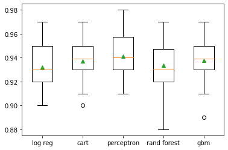

```python
# Split dataset
X = df_encoded.iloc[:, :-1]
y = df_encoded.iloc[:, -1]

# evaluate the models and store results

# We select n features to 15 because we think that from 20 features...
# there are redundant features after one hot encoding, like we can drop 1 column but it's still represent the dataset itself
# (Column: gender, race/ethnicity, parental level of education, lunch, test preparation course) = 5 columns
n_features_to_select = 15

models = get_models(X, y, n_features_to_select)

results, names = list(), list()
for name, model in models.items():
    scores = evaluate_model(model, X, y)
    results.append(scores)
    names.append(name)
    print('> %s %.3f (%.3f)' % (name, mean(scores), std(scores)))

# plot model performance for comparison
pyplot.boxplot(results, labels=names, showmeans=True)
pyplot.show()
```

↑ ↑ As we can see.. "perceptron" has the highest accuracy, so we take "perception" model as our estimator

```python
def get_model_perceptron(X, y, n: int):
    models = dict()
    rfe = RFE(estimator=Perceptron(), n_features_to_select=n)
    model = DecisionTreeClassifier()
    models['perceptron'] = Pipeline(steps=[('s',rfe),('m',model)])
    rfe.fit(X, y)
    return models, rfe.support_, rfe.ranking_

# Ranking the features
percp = get_model_perceptron(X, y, n_features_to_select)
print(f"Selected feat. :{percp[1]}")
print(f"Features rank  : {percp[2]}")
```

```
Selected feat. :[ True  True False False  True  True  True  True False False  True False
  True  True  True  True  True  True  True  True]
Features rank  : [1 1 5 4 1 1 1 1 2 6 1 3 1 1 1 1 1 1 1 1]
```

```python
selected_fetures = [i for i, s in enumerate(percp[1]) if s]
print(f"Selected features: {selected_fetures}")

df_RFE = df_encoded.iloc[:, selected_fetures]
df_RFE["average"] = y

# Let's see the final dataset after features selection (RFE)
display(df_RFE.head(2))
print(df_RFE.shape)
```

```
Selected features: [0, 1, 4, 5, 6, 7, 10, 12, 13, 14, 15, 16, 17, 18, 19]
```

|  | gender_female | gender_male | race/ethnicity_group C | race/ethnicity_group D | race/ethnicity_group E | parental level of education_associate's degree | parental level of education_master's degree | parental level of education_some high school | lunch_free/reduced | lunch_standard | test preparation course_completed | test preparation course_none | math_PassStatus | read_PassStatus | write_PassStatus | average |
| --- | --- | --- | --- | --- | --- | --- | --- | --- | --- | --- | --- | --- | --- | --- | --- | --- |
| 0 | 0 | 1 | 0 | 0 | 0 | 0 | 0 | 0 | 0 | 1 | 1 | 0 | 1 | 1 | 1 | 1 |
| 1 | 1 | 0 | 0 | 1 | 0 | 0 | 0 | 1 | 1 | 0 | 0 | 1 | 0 | 0 | 0 | 0 |

```
(999, 16)
```

↑ ↑ Final dataset after features selection (RFE)

#### 2. Features selection chi-square

```python
# Display datase after one hot encoding
df_encoded.head(2)
```

|  | gender_female | gender_male | race/ethnicity_group A | race/ethnicity_group B | race/ethnicity_group C | race/ethnicity_group D | race/ethnicity_group E | parental level of education_associate's degree | parental level of education_bachelor's degree | parental level of education_high school | ... | parental level of education_some college | parental level of education_some high school | lunch_free/reduced | lunch_standard | test preparation course_completed | test preparation course_none | math_PassStatus | read_PassStatus | write_PassStatus | overall_PassStatus |
| --- | --- | --- | --- | --- | --- | --- | --- | --- | --- | --- | --- | --- | --- | --- | --- | --- | --- | --- | --- | --- | --- |
| 0 | 0 | 1 | 1 | 0 | 0 | 0 | 0 | 0 | 0 | 1 | ... | 0 | 0 | 0 | 1 | 1 | 0 | 1 | 1 | 1 | 1 |
| 1 | 1 | 0 | 0 | 0 | 0 | 1 | 0 | 0 | 0 | 0 | ... | 0 | 1 | 1 | 0 | 0 | 1 | 0 | 0 | 0 | 0 |

2 rows × 21 columns

```python
# Split dataset
X = df_encoded.iloc[:, :-1]
y = df_encoded.iloc[:, -1]

# Features selection based on chi-square score
fs = SelectKBest(score_func=chi2, k='all')
fs.fit(X, y)
X_train_fs = fs.transform(X)

# Get chi-square score for all columns
features_score = fs.scores_
features_score = features_score.tolist()

print(f"Features score:\n{features_score}")
```

[output not shown]

↑ ↑ Done features selection chi-square ✔

```python
def selection_sort_and_keep_track_the_original_index(features_score):
    temp = [i for i in range(len(features_score))]
    for i in range(0, len(features_score)-1):
        for j in range(i+1, len(features_score)):
            if features_score[i] > features_score[j]:
                features_score[i], features_score[j] = features_score[j], features_score[i]
                temp[i], temp[j] = temp[j], temp[i]

    return list(zip(temp, features_score))


final_features = selection_sort_and_keep_track_the_original_index(features_score)
print(final_features)
```

[output not shown]

↑ ↑ We sort the chi-square features socre but keep tracking the original index (Don't run it twice)

```python
# Next we just need to display the final dataset

# We select best of 15 features out of 20 based on our RFE above
final_features = [g[0] for g in (final_features[5:])]

df_cs = df_encoded.iloc[:, final_features]
df_cs["average"] = y

display(df_cs)
```

|  | parental level of education_some college | race/ethnicity_group E | parental level of education_master's degree | parental level of education_bachelor's degree | parental level of education_associate's degree | race/ethnicity_group D | race/ethnicity_group C | test preparation course_none | parental level of education_some high school | test preparation course_completed | lunch_standard | lunch_free/reduced | read_PassStatus | math_PassStatus | write_PassStatus | average |
| --- | --- | --- | --- | --- | --- | --- | --- | --- | --- | --- | --- | --- | --- | --- | --- | --- |
| 0 | 0 | 0 | 0 | 0 | 0 | 0 | 0 | 0 | 0 | 1 | 1 | 0 | 1 | 1 | 1 | 1 |
| 1 | 0 | 0 | 0 | 0 | 0 | 1 | 0 | 1 | 1 | 0 | 0 | 1 | 0 | 0 | 0 | 0 |
| 2 | 1 | 1 | 0 | 0 | 0 | 0 | 0 | 1 | 0 | 0 | 0 | 1 | 1 | 0 | 0 | 0 |
| 3 | 0 | 0 | 0 | 0 | 0 | 0 | 0 | 1 | 0 | 0 | 1 | 0 | 1 | 1 | 1 | 1 |
| 4 | 0 | 1 | 0 | 0 | 1 | 0 | 0 | 0 | 0 | 1 | 1 | 0 | 1 | 1 | 1 | 1 |
| ... | ... | ... | ... | ... | ... | ... | ... | ... | ... | ... | ... | ... | ... | ... | ... | ... |
| 995 | 0 | 0 | 0 | 0 | 0 | 0 | 1 | 1 | 0 | 0 | 1 | 0 | 1 | 1 | 1 | 1 |
| 996 | 0 | 0 | 0 | 0 | 1 | 1 | 0 | 0 | 0 | 1 | 0 | 1 | 1 | 1 | 1 | 1 |
| 997 | 0 | 0 | 0 | 0 | 0 | 0 | 1 | 1 | 1 | 0 | 0 | 1 | 0 | 0 | 0 | 0 |
| 998 | 1 | 0 | 0 | 0 | 0 | 0 | 1 | 1 | 0 | 0 | 1 | 0 | 1 | 1 | 1 | 1 |
| 999 | 1 | 0 | 0 | 0 | 0 | 0 | 0 | 0 | 0 | 1 | 1 | 0 | 1 | 1 | 1 | 1 |

999 rows × 16 columns

↑ ↑ Final dataset after features selection (chi-square)

### Summary (answering the problem define description above)

```python
# Display original dataset (but with new column "average")
df
```

|  | gender | race/ethnicity | parental level of education | lunch | test preparation course | math score | reading score | writing score | average |
| --- | --- | --- | --- | --- | --- | --- | --- | --- | --- |
| 0 | male | group A | high school | standard | completed | 67.0 | 67.0 | 63.0 | 65.666667 |
| 1 | female | group D | some high school | free/reduced | none | 40.0 | 59.0 | 55.0 | 51.333333 |
| 2 | male | group E | some college | free/reduced | none | 59.0 | 60.0 | 50.0 | 56.333333 |
| 3 | male | group B | high school | standard | none | 77.0 | 78.0 | 68.0 | 74.333333 |
| 4 | male | group E | associate's degree | standard | completed | 78.0 | 73.0 | 68.0 | 73.000000 |
| ... | ... | ... | ... | ... | ... | ... | ... | ... | ... |
| 995 | male | group C | high school | standard | none | 73.0 | 70.0 | 65.0 | 69.333333 |
| 996 | male | group D | associate's degree | free/reduced | completed | 85.0 | 91.0 | 92.0 | 89.333333 |
| 997 | female | group C | some high school | free/reduced | none | 32.0 | 35.0 | 41.0 | 36.000000 |
| 998 | female | group C | some college | standard | none | 73.0 | 74.0 | 82.0 | 76.333333 |
| 999 | male | group A | some college | standard | completed | 65.0 | 60.0 | 62.0 | 62.333333 |

999 rows × 9 columns

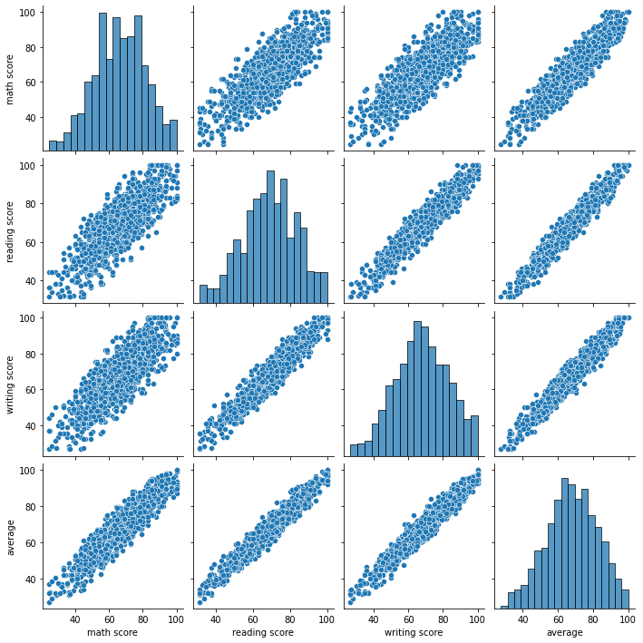

```python
# Let's see the distribution
sns.pairplot(df)
```

#### a. How effective is the test preparation course?

[output not shown]

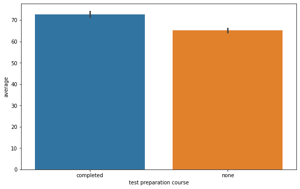

```python
# We plot to barplot so we can see the corelation
figure, ax = plt.subplots(1,1, constrained_layout=True, figsize=(8, 5))
plt.subplot(1, 1, 1)
sns.barplot(df['test preparation course'], df['average'])
```

```python
# Let's see value counts for "test preparation course"
df['test preparation course'].value_counts()
```

```
none         665
completed    334
Name: test preparation course, dtype: int64
```

↑ ↑ From barplot above... we can see that the "test preparation course" is quite effective in peforming student's exams score

There is a different between "completed" and "none"  
The average of exams score of the completed "test preparation course" is higher than those who not (none) completed "test preparation course"  
So we can say that "test preparation course" is quite effective ✔

#### b. Which major factors contribute to test outcomes?

```
        math score  reading score  writing score    average
gender
female   63.247412      71.898551      71.715321  68.953761
male     69.325581      66.263566      63.971899  66.520349
                math score  reading score  writing score    average
race/ethnicity
group A          65.215190      68.556962      66.974684  66.915612
group B          63.170732      67.148780      65.765854  65.361789
group C          63.170279      66.407121      64.535604  64.704334
group D          69.311069      72.087786      72.259542  71.219466
group E          74.269231      72.315385      69.984615  72.189744
                             math score  reading score  writing score  \
parental level of education
associate's degree            69.393564      70.841584      69.965347
bachelor's degree             71.491071      74.008929      74.410714
high school                   65.207921      67.418317      64.863861
master's degree               71.585714      75.428571      75.885714
some college                  65.400901      68.103604      66.763514
some high school              60.701571      64.410995      62.539267

                               average
parental level of education
associate's degree           70.066832
bachelor's degree            73.303571
high school                  65.830033
master's degree              74.300000
some college                 66.756006
some high school             62.550611
              math score  reading score  writing score    average
lunch
free/reduced   58.576149      63.238506      60.954023  60.922893
standard       70.562212      72.061444      71.330261  71.317972
                         math score  reading score  writing score    average
test preparation course
completed                 69.595808      74.019461      74.595808  72.737026
none                      64.775188      66.460902      64.260150  65.165414
```

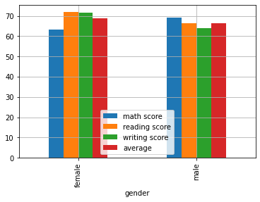

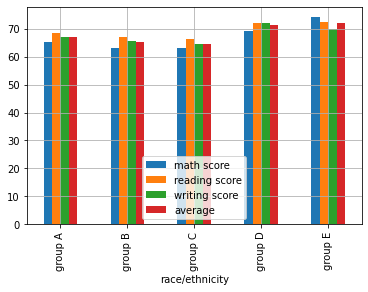

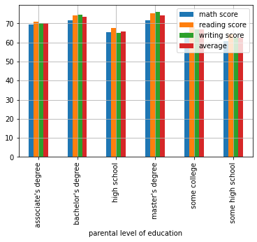

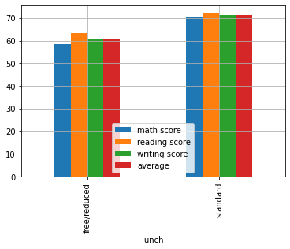

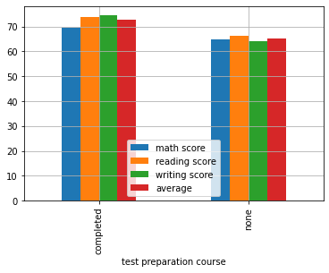

```python
# Let's bar plot 5 input columns and check which has the most significant difference
output = ['math score','reading score','writing score','average']

for x in df.columns[:-4]:
    scores=df.groupby(x)[output].mean()
    print(scores)
    scores.plot(kind='bar',grid=True )
```

#### c. What would be the best way to improve student scores on each test?

It's easy after we see all the 5 barplot above in cell "b". The "lunch" is a key and a simple problem and solution to improve student scores (based on each test/average)

#### d. What patterns and interactions in the data can you find?

[output not shown]

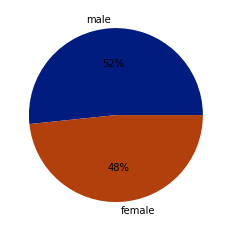

```python
palette_color = sns.color_palette('dark')
plt.pie(df["gender"].value_counts(), labels=["male", "female"], colors=palette_color, autopct='%.0f%%')
```

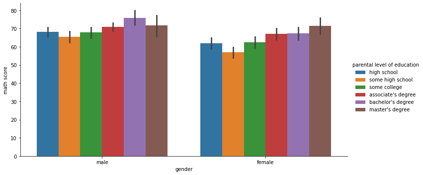

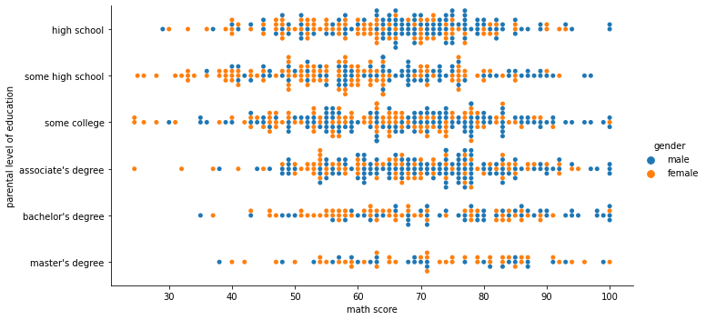

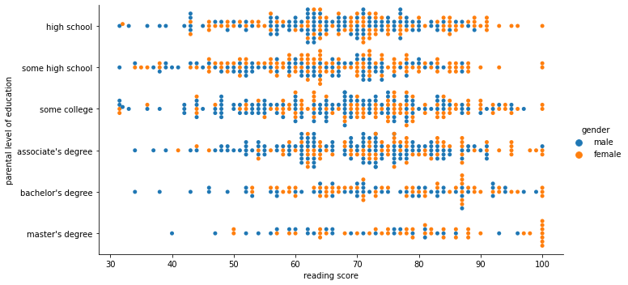

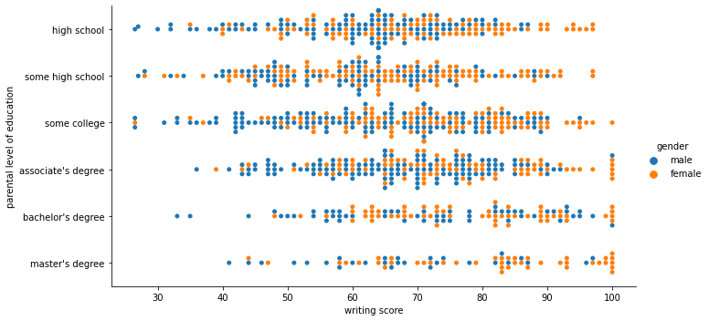

```python
plt.figure(figsize=(10,10))
sns.catplot(x="gender", y="math score", hue="parental level of education", data=df, kind='bar', height=5, aspect=2)
plt.show()
sns.catplot(data=df, x="math score", y="parental level of education", hue="gender", kind="swarm" ,height=5, aspect=2)
plt.figure(figsize=(10,10))
sns.catplot(data=df, x="reading score", y="parental level of education", hue="gender", kind="swarm" ,height=5, aspect=2)
plt.figure(figsize=(10,10))
sns.catplot(data=df, x="writing score", y="parental level of education", hue="gender", kind="swarm" ,height=5, aspect=2)
plt.figure(figsize=(10,10))
```

From barplot before and chart above, we can observe...

- Students with a higher parental's degrees have more chances to achieve a higher scores
- Based on gender, female have higher score average than male
- The females dominate the higher scores in reading and writing
- Male outperform female in ONLY math
- Along this dataset female and male students are equally distributed
- "Lunch" is quite influential in performing student's exams score